# project_2

Project 2 : Investigate a dataset

Table of Contents:

1-Introduction

2-Data Wrangling

3-Exploratory Data Analysis

4-Conclusions

Introduction : Dataset I have chosen for analysis: The Movie Database TMDB movies (TMDb) This data set contains information about 10,000 movies collected from The Movie Database TMDB movies (TMDb),including user ratings and revenue.

Description of the dataset columns :

Column Description

Id Rows unique id

imdb_id imdb unique id

popularity popularity score

budget budget of movie

original_title Movie title

Cast cast in movie

homepage link to movie website

director movie director name

tagline tagline of movie

keywords movie keywords

overview overview of movie

runtime movie duration in minutes

genres movie category

production_companies name of company that produced movie

release_date release date of movie

vote_count vote casted by viewers or reviewers vote_average average vote casted by viewers or reviewers

release_year year movie was released

budget_adj budget in 2010 dollars,accounting for inflation revenue_adj revenue in 2010 dollars,accounting for inflation

My Questions are :

1- Which genres are most popular from year to year?

2- What is the Correlation between profit and budget

3- Which year made the highest and lowest profit ?

4- What are movies runtime the most popular to movies viewers ?

5- which the movie have lowest and highest budget ?

6- which the movie have lowest and highest profit ?

7- which movies with the top 10 budget?

Data Wrangling:

I will explore the data, look for possibility for data cleansing , and then prepare and clean chosen dataset for analysis.

```python
# #importing statements for all of the packages that will be used
import pandas as pd
import numpy as np
import matplotlib.pyplot as plt
# #%matplotlib inline
```

```python
#load the data and print first ten rows to check data
statmov = pd.read_csv('tmdb-movies.csv')
statmov.head(10)
```

|  | id | imdb_id | popularity | budget | revenue | original_title | cast | homepage | director | tagline | ... | overview | runtime | genres | production_companies | release_date | vote_count | vote_average | release_year | budget_adj | revenue_adj |
| --- | --- | --- | --- | --- | --- | --- | --- | --- | --- | --- | --- | --- | --- | --- | --- | --- | --- | --- | --- | --- | --- |
| 0 | 135397 | tt0369610 | 32.985763 | 150000000 | 1513528810 | Jurassic World | Chris Pratt\|Bryce Dallas Howard\|Irrfan Khan\|Vi... | http://www.jurassicworld.com/ | Colin Trevorrow | The park is open. | ... | Twenty-two years after the events of Jurassic ... | 124 | Action\|Adventure\|Science Fiction\|Thriller | Universal Studios\|Amblin Entertainment\|Legenda... | 6/9/15 | 5562 | 6.5 | 2015 | 1.379999e+08 | 1.392446e+09 |
| 1 | 76341 | tt1392190 | 28.419936 | 150000000 | 378436354 | Mad Max: Fury Road | Tom Hardy\|Charlize Theron\|Hugh Keays-Byrne\|Nic... | http://www.madmaxmovie.com/ | George Miller | What a Lovely Day. | ... | An apocalyptic story set in the furthest reach... | 120 | Action\|Adventure\|Science Fiction\|Thriller | Village Roadshow Pictures\|Kennedy Miller Produ... | 5/13/15 | 6185 | 7.1 | 2015 | 1.379999e+08 | 3.481613e+08 |
| 2 | 262500 | tt2908446 | 13.112507 | 110000000 | 295238201 | Insurgent | Shailene Woodley\|Theo James\|Kate Winslet\|Ansel... | http://www.thedivergentseries.movie/#insurgent | Robert Schwentke | One Choice Can Destroy You | ... | Beatrice Prior must confront her inner demons ... | 119 | Adventure\|Science Fiction\|Thriller | Summit Entertainment\|Mandeville Films\|Red Wago... | 3/18/15 | 2480 | 6.3 | 2015 | 1.012000e+08 | 2.716190e+08 |
| 3 | 140607 | tt2488496 | 11.173104 | 200000000 | 2068178225 | Star Wars: The Force Awakens | Harrison Ford\|Mark Hamill\|Carrie Fisher\|Adam D... | http://www.starwars.com/films/star-wars-episod... | J.J. Abrams | Every generation has a story. | ... | Thirty years after defeating the Galactic Empi... | 136 | Action\|Adventure\|Science Fiction\|Fantasy | Lucasfilm\|Truenorth Productions\|Bad Robot | 12/15/15 | 5292 | 7.5 | 2015 | 1.839999e+08 | 1.902723e+09 |
| 4 | 168259 | tt2820852 | 9.335014 | 190000000 | 1506249360 | Furious 7 | Vin Diesel\|Paul Walker\|Jason Statham\|Michelle ... | http://www.furious7.com/ | James Wan | Vengeance Hits Home | ... | Deckard Shaw seeks revenge against Dominic Tor... | 137 | Action\|Crime\|Thriller | Universal Pictures\|Original Film\|Media Rights ... | 4/1/15 | 2947 | 7.3 | 2015 | 1.747999e+08 | 1.385749e+09 |
| 5 | 281957 | tt1663202 | 9.110700 | 135000000 | 532950503 | The Revenant | Leonardo DiCaprio\|Tom Hardy\|Will Poulter\|Domhn... | http://www.foxmovies.com/movies/the-revenant | Alejandro González Iñárritu | (n. One who has returned, as if from the dead.) | ... | In the 1820s, a frontiersman, Hugh Glass, sets... | 156 | Western\|Drama\|Adventure\|Thriller | Regency Enterprises\|Appian Way\|CatchPlay\|Anony... | 12/25/15 | 3929 | 7.2 | 2015 | 1.241999e+08 | 4.903142e+08 |
| 6 | 87101 | tt1340138 | 8.654359 | 155000000 | 440603537 | Terminator Genisys | Arnold Schwarzenegger\|Jason Clarke\|Emilia Clar... | http://www.terminatormovie.com/ | Alan Taylor | Reset the future | ... | The year is 2029. John Connor, leader of the r... | 125 | Science Fiction\|Action\|Thriller\|Adventure | Paramount Pictures\|Skydance Productions | 6/23/15 | 2598 | 5.8 | 2015 | 1.425999e+08 | 4.053551e+08 |
| 7 | 286217 | tt3659388 | 7.667400 | 108000000 | 595380321 | The Martian | Matt Damon\|Jessica Chastain\|Kristen Wiig\|Jeff ... | http://www.foxmovies.com/movies/the-martian | Ridley Scott | Bring Him Home | ... | During a manned mission to Mars, Astronaut Mar... | 141 | Drama\|Adventure\|Science Fiction | Twentieth Century Fox Film Corporation\|Scott F... | 9/30/15 | 4572 | 7.6 | 2015 | 9.935996e+07 | 5.477497e+08 |
| 8 | 211672 | tt2293640 | 7.404165 | 74000000 | 1156730962 | Minions | Sandra Bullock\|Jon Hamm\|Michael Keaton\|Allison... | http://www.minionsmovie.com/ | Kyle Balda\|Pierre Coffin | Before Gru, they had a history of bad bosses | ... | Minions Stuart, Kevin and Bob are recruited by... | 91 | Family\|Animation\|Adventure\|Comedy | Universal Pictures\|Illumination Entertainment | 6/17/15 | 2893 | 6.5 | 2015 | 6.807997e+07 | 1.064192e+09 |
| 9 | 150540 | tt2096673 | 6.326804 | 175000000 | 853708609 | Inside Out | Amy Poehler\|Phyllis Smith\|Richard Kind\|Bill Ha... | http://movies.disney.com/inside-out | Pete Docter | Meet the little voices inside your head. | ... | Growing up can be a bumpy road, and it's no ex... | 94 | Comedy\|Animation\|Family | Walt Disney Pictures\|Pixar Animation Studios\|W... | 6/9/15 | 3935 | 8.0 | 2015 | 1.609999e+08 | 7.854116e+08 |

10 rows × 21 columns

dataset contains 10866 rows and 21 columns.

I will check the dataset for necessary correction for example correct datatypes or null values in dataset columns

```python
statmov.info()
```

```
<class 'pandas.core.frame.DataFrame'>
RangeIndex: 10866 entries, 0 to 10865
Data columns (total 21 columns):
 #   Column                Non-Null Count  Dtype
---  ------                --------------  -----
 0   id                    10866 non-null  int64
 1   imdb_id               10856 non-null  object
 2   popularity            10866 non-null  float64
 3   budget                10866 non-null  int64
 4   revenue               10866 non-null  int64
 5   original_title        10866 non-null  object
 6   cast                  10790 non-null  object
 7   homepage              2936 non-null   object
 8   director              10822 non-null  object
 9   tagline               8042 non-null   object
 10  keywords              9373 non-null   object
 11  overview              10862 non-null  object
 12  runtime               10866 non-null  int64
 13  genres                10843 non-null  object
 14  production_companies  9836 non-null   object
 15  release_date          10866 non-null  object
 16  vote_count            10866 non-null  int64
 17  vote_average          10866 non-null  float64
 18  release_year          10866 non-null  int64
 19  budget_adj            10866 non-null  float64
 20  revenue_adj           10866 non-null  float64
dtypes: float64(4), int64(6), object(11)
memory usage: 1.7+ MB
```

I will drop some columns I do not use to be efficient for data analysis

```python
#I can drop some columns for data quality and to be usefull for analysis
statmov.drop([ 'cast' , 'homepage' , 'tagline' , 'keywords' , 'overview','vote_count' , 'vote_average' , 'imdb_id'], axis=1,inplace =True)
```

```python
statmov.shape
```

```
(10866, 13)
```

I will drop rows with any null values in dataset

```python
# dropping rows with any null values in dataset
statmov.dropna(inplace=True)
```

```python
statmov.info()
```

```
<class 'pandas.core.frame.DataFrame'>
Int64Index: 9807 entries, 0 to 10865
Data columns (total 13 columns):
 #   Column                Non-Null Count  Dtype
---  ------                --------------  -----
 0   id                    9807 non-null   int64
 1   popularity            9807 non-null   float64
 2   budget                9807 non-null   int64
 3   revenue               9807 non-null   int64
 4   original_title        9807 non-null   object
 5   director              9807 non-null   object
 6   runtime               9807 non-null   int64
 7   genres                9807 non-null   object
 8   production_companies  9807 non-null   object
 9   release_date          9807 non-null   object
 10  release_year          9807 non-null   int64
 11  budget_adj            9807 non-null   float64
 12  revenue_adj           9807 non-null   float64
dtypes: float64(3), int64(5), object(5)
memory usage: 1.0+ MB
```

i notice that datatype "release_date" column need to be corrected

```python
#correct datatype for release_date from object type to date type
statmov['release_date'] = pd.to_datetime(statmov['release_date'])
```

```python
#checking for changing dtatype
statmov.dtypes
```

```
id                               int64
popularity                     float64
budget                           int64
revenue                          int64
original_title                  object
director                        object
runtime                          int64
genres                          object
production_companies            object
release_date            datetime64[ns]
release_year                     int64
budget_adj                     float64
revenue_adj                    float64
dtype: object
```

```python
statmov.info()
```

```
<class 'pandas.core.frame.DataFrame'>
Int64Index: 9807 entries, 0 to 10865
Data columns (total 13 columns):
 #   Column                Non-Null Count  Dtype
---  ------                --------------  -----
 0   id                    9807 non-null   int64
 1   popularity            9807 non-null   float64
 2   budget                9807 non-null   int64
 3   revenue               9807 non-null   int64
 4   original_title        9807 non-null   object
 5   director              9807 non-null   object
 6   runtime               9807 non-null   int64
 7   genres                9807 non-null   object
 8   production_companies  9807 non-null   object
 9   release_date          9807 non-null   datetime64[ns]
 10  release_year          9807 non-null   int64
 11  budget_adj            9807 non-null   float64
 12  revenue_adj           9807 non-null   float64
dtypes: datetime64[ns](1), float64(3), int64(5), object(4)
memory usage: 1.0+ MB
```

study and understand data distributions by making visualizing in histogram

```
array([[<AxesSubplot:title={'center':'id'}>,
        <AxesSubplot:title={'center':'popularity'}>,
        <AxesSubplot:title={'center':'budget'}>],
       [<AxesSubplot:title={'center':'revenue'}>,
        <AxesSubplot:title={'center':'runtime'}>,
        <AxesSubplot:title={'center':'release_date'}>],
       [<AxesSubplot:title={'center':'release_year'}>,
        <AxesSubplot:title={'center':'budget_adj'}>,
        <AxesSubplot:title={'center':'revenue_adj'}>]], dtype=object)
```

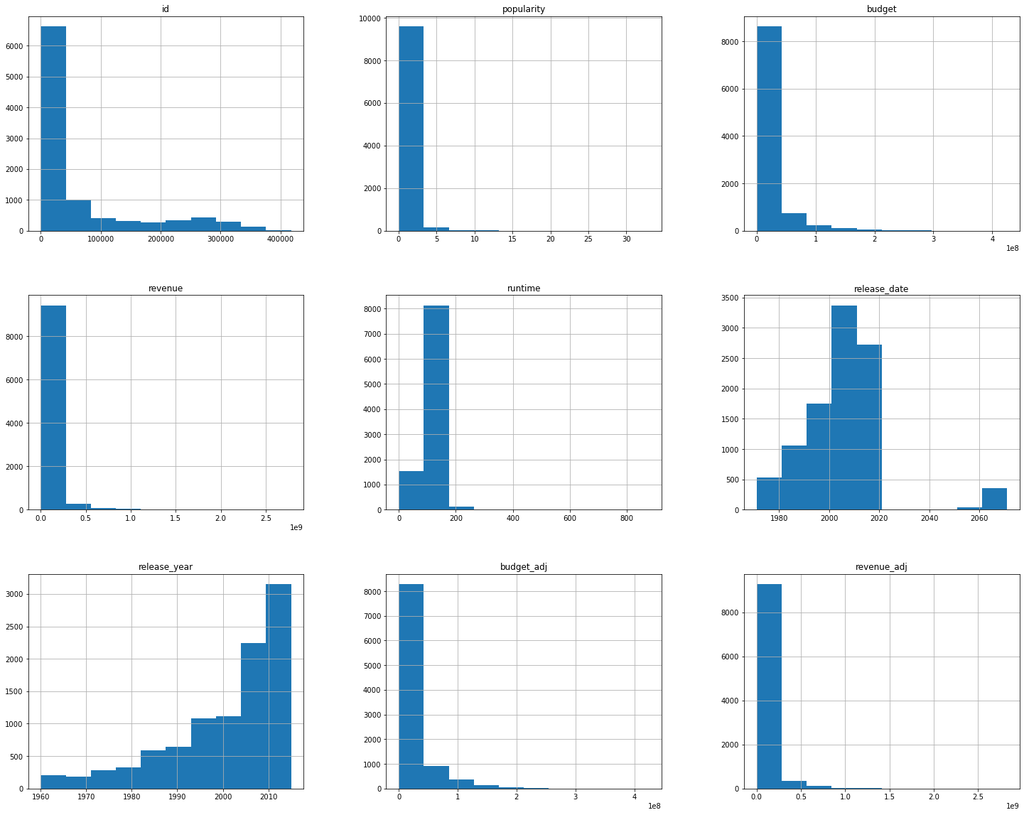

```python
statmov.hist(figsize=(25,20))
```

```python
statmov.describe()
```

|  | id | popularity | budget | revenue | runtime | release_year | budget_adj | revenue_adj |
| --- | --- | --- | --- | --- | --- | --- | --- | --- |
| count | 9807.000000 | 9807.000000 | 9.807000e+03 | 9.807000e+03 | 9807.000000 | 9807.000000 | 9.807000e+03 | 9.807000e+03 |
| mean | 63285.502906 | 0.693133 | 1.612666e+07 | 4.407345e+07 | 102.743245 | 2000.891200 | 1.935178e+07 | 5.684958e+07 |
| std | 90804.092475 | 1.035473 | 3.216685e+07 | 1.223983e+08 | 28.133335 | 13.032032 | 3.562014e+07 | 1.512176e+08 |
| min | 5.000000 | 0.000188 | 0.000000e+00 | 0.000000e+00 | 0.000000 | 1960.000000 | 0.000000e+00 | 0.000000e+00 |
| 25% | 10248.000000 | 0.231584 | 0.000000e+00 | 0.000000e+00 | 90.000000 | 1994.000000 | 0.000000e+00 | 0.000000e+00 |
| 50% | 18726.000000 | 0.418900 | 1.457860e+05 | 0.000000e+00 | 100.000000 | 2005.000000 | 2.423044e+05 | 0.000000e+00 |
| 75% | 70586.500000 | 0.774204 | 1.900000e+07 | 3.063954e+07 | 112.000000 | 2011.000000 | 2.442295e+07 | 4.254888e+07 |
| max | 417859.000000 | 32.985763 | 4.250000e+08 | 2.781506e+09 | 877.000000 | 2015.000000 | 4.250000e+08 | 2.827124e+09 |

I will replace zero values in columns budget , revenue , runtime with means in this each column

```python
#replacing zero  values in columns budget ,  revenue , runtime  with  means in this each column
statmov[ 'budget' ]=statmov[ 'budget' ].replace(0,statmov[ 'budget' ].mean())
statmov['revenue'] =statmov['revenue'].replace(0,statmov['revenue'].mean())
statmov[ 'runtime' ]=statmov[ 'runtime' ].replace(0,statmov[ 'runtime' ].mean())
```

```python
statmov.describe()
```

|  | id | popularity | budget | revenue | runtime | release_year | budget_adj | revenue_adj |
| --- | --- | --- | --- | --- | --- | --- | --- | --- |
| count | 9807.000000 | 9807.000000 | 9.807000e+03 | 9.807000e+03 | 9807.000000 | 9807.000000 | 9.807000e+03 | 9.807000e+03 |
| mean | 63285.502906 | 0.693133 | 2.398198e+07 | 6.678654e+07 | 102.879439 | 2000.891200 | 1.935178e+07 | 5.684958e+07 |
| std | 90804.092475 | 1.035473 | 2.909126e+07 | 1.160356e+08 | 27.883176 | 13.032032 | 3.562014e+07 | 1.512176e+08 |
| min | 5.000000 | 0.000188 | 1.000000e+00 | 2.000000e+00 | 2.000000 | 1960.000000 | 0.000000e+00 | 0.000000e+00 |
| 25% | 10248.000000 | 0.231584 | 1.612666e+07 | 3.540204e+07 | 90.000000 | 1994.000000 | 0.000000e+00 | 0.000000e+00 |
| 50% | 18726.000000 | 0.418900 | 1.612666e+07 | 4.407345e+07 | 100.000000 | 2005.000000 | 2.423044e+05 | 0.000000e+00 |
| 75% | 70586.500000 | 0.774204 | 1.900000e+07 | 4.407345e+07 | 112.000000 | 2011.000000 | 2.442295e+07 | 4.254888e+07 |
| max | 417859.000000 | 32.985763 | 4.250000e+08 | 2.781506e+09 | 877.000000 | 2015.000000 | 4.250000e+08 | 2.827124e+09 |

To make generes column more normalize

```python
statmov['genres'] = statmov['genres'].apply(lambda x: x.split('|')[0])
```

Exploratory Data Analysis:

Analyzing dataset after data cleansing

-To answer my first quetion i will study the relationship between the "genres" of movies and popularity

```
genres
Action             0.875737
Adventure          1.275178
Animation          0.871280
Comedy             0.572296
Crime              0.719409
Documentary        0.209573
Drama              0.587012
Family             0.783861
Fantasy            0.907793
Foreign            0.232168
History            0.839363
Horror             0.487790
Music              0.528743
Mystery            0.621116
Romance            0.786560
Science Fiction    1.156476
TV Movie           0.268062
Thriller           0.691054
War                0.789277
Western            0.690646
Name: popularity, dtype: float64
```

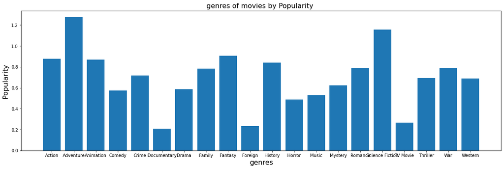

```python
genres_by_movie_popularity= statmov.groupby(['genres'])['popularity'].mean()
print (genres_by_movie_popularity)
plt.subplots(figsize=(20, 6))
plt.bar(genres_by_movie_popularity.index, genres_by_movie_popularity)
plt.title('genres of movies by Popularity ', color = 'black', fontsize = '16')
plt.xlabel('genres', color = 'black', fontsize = '16')
plt.ylabel('Popularity ', color = 'black', fontsize = '16');
```

From the above figure we conclude that the Adventure movies is the most most popular genre of all movies